# Introduction

With the recent widespread legalizing of state-level sports gambling - online betting houses release a multitude of lines to the public that individuals are able to wager on. Some of these are team wagers, such as whether or not the Blackhawks will win by atleast 1.5 goals or if the Stanley Cup champion will come from the Eastern Conference. To go along with these wagers, individuals can wager on specific aspects of an individual game - such as goals for an individual team, which players will score those goals and the timing of those goals.

Here we will investigate the frequency of players scoring goals. There are several key factors that come with wagering on a player scoring during the course of an NHL game. They are:

1) The individual cannot bet against a player to score.  
2) The individual can bet on the player scoring first during the game, at anytime during the game or being the last goal-scorer.  
3) Lines for the individual players are widely available through many betting houses, but are not able to be manipulated by the individual placing the bet.

Here we will provide a method for investigating whether or not we should place a bet on a player scoring over the course of the night. In an effort to leverage a statistical hypothesis test to create some degree of rigor around our evaluation, we will use two common statistical tests: A runs test and a binomial tail test. These two tests should help allow us to identify opportunities to wager on an individual player that is fundamentally mispriced by the betting house.

**The steps are broadly:** 1) Collect game-by-game data of NHL Players, specifically whether or not the player has scored.  
2) Perform a runs test to see whether or not that players scoring patterns are random or not.  
3) Identify and collect the lines that the intended betting house will be offering for specific players.  
4) Compare that line (and implied probability) to how often the player has scored over the course of the season via a hypothesis test to determine whether or not it is likely that the implied probability is underestimated and we should place a wager.

For more information on the first step, I highly recommend further reading of this documentation of the NHLs API, which is an absolutely incredible resource for collecting player, team and game data from a consistent and reliable source. More information can be found at:

https://gitlab.com/dword4/nhlapi

# NHL Game Setting

To set the context of these tests, we will be using the game between the Toronto Maple Leafs and Chicago Blackhawks. This game occured on 3/13 in Chicago and had a multitude of wagering opportunities for the Toronto Maple Leafs players. A snippet of some of the top Maple Leafs players odds can be shown below.

```python
#Import all necessary libraries
import requests
import pandas as pd
import numpy as np

#Import our utility functions to scrape the web for player information
from utils import get_teams_info, get_team_data, get_player_game_data, get_game_by_game_splits

#Import our statistical modeling tools
from statsmodels.sandbox.stats.runs import runstest_1samp
from scipy.stats import binomtest
```

# Importing Data

Here we will collect data concerning the Toronto Maple Leafs players over the course of the season for our evaluation.

```python
ML_game_data = get_game_by_game_splits(team_id = 10, season = 20222023)
```

```python
ML_game_data.head()
```

|  | game_id | season | teamPlayer_id | teamPlayer_name | teamOpponent_id | teamOpponent_name | date | player_id | player_name | home | goals | assists | plus_minus |
| --- | --- | --- | --- | --- | --- | --- | --- | --- | --- | --- | --- | --- | --- |
| 0 | 2022020040 | 20222023 | 10 | Toronto Maple Leafs | 53 | Arizona Coyotes | 2022-10-17 | 8474162 | Jake Muzzin | True | 0.0 | 0.0 | 0.0 |
| 1 | 2022020030 | 20222023 | 10 | Toronto Maple Leafs | 9 | Ottawa Senators | 2022-10-15 | 8474162 | Jake Muzzin | True | 0.0 | 1.0 | 2.0 |
| 2 | 2022020015 | 20222023 | 10 | Toronto Maple Leafs | 15 | Washington Capitals | 2022-10-13 | 8474162 | Jake Muzzin | True | 0.0 | 0.0 | 0.0 |
| 3 | 2022020007 | 20222023 | 10 | Toronto Maple Leafs | 8 | Montréal Canadiens | 2022-10-12 | 8474162 | Jake Muzzin | False | 0.0 | 0.0 | -2.0 |
| 0 | 2022020996 | 20222023 | 10 | Toronto Maple Leafs | 23 | Vancouver Canucks | 2023-03-04 | 8475158 | Ryan O'Reilly | False | 0.0 | 0.0 | 0.0 |

# Runs Test

Next we create the framework to perform several hypothesis tests for the players on the Maple Leafs. We will want to set a limit for the player to have played in atleast 10 games this season, both for the tests performance but also for our own sanity. If we were to employ this strategy league-wide, we would want to only include players who have some consistency in their playing time.

We use a alpha level of .05 and compare the output of the runs test to that output.

In a runs test:

H<sub>o</sub>: The sequence was produced in a random manner  
H<sub>a</sub>: The sequence was not produced in a random manner

The alternative hypothesis being that the sequence was not producred in a random manner would allow us to say that there might be some level of pattern within the data.

What we are trying to tease out here is whether or not an individual player is "streaky" or can we say that their previous game performance is indicative of the next games performance?

More information on runs tests can be found https://www.itl.nist.gov/div898/handbook/eda/section3/eda35d.htm

```python
def runs_test(df, pval = .05):
    '''df: input of game by game data for a particular team
      pval: the level of signficance used in the runs test'''
    results_df = pd.DataFrame(columns = ['player_name','result','pval'])
    for x in df['player_name'].unique():
        if (len(df[df['player_name']==x]) > 10) & (sum(df[df['player_name'] == x]['goals']) > 0):
            if runstest_1samp(df[df['player_name']==x]['goals'], cutoff =.5)[1] > pval:
                results_df.loc[len(results_df)] = [x,'random',runstest_1samp(df[df['player_name']==x]['goals'])[1]]
            else:
                results_df.loc[len(results_df)] = [x,'not random',runstest_1samp(df[df['player_name']==x]['goals'])[1]]
    return results_df
```

```python
ML_runs = runs_test(ML_game_data, pval = .05)
```

```python
ML_runs
```

|  | player_name | result | pval |
| --- | --- | --- | --- |
| 0 | Ryan O'Reilly | random | 0.840499 |
| 1 | Nicholas Robertson | random | 0.280749 |
| 2 | Mark Giordano | random | 0.077447 |
| 3 | Luke Schenn | random | 0.646973 |
| 4 | TJ Brodie | random | 0.171042 |
| 5 | John Tavares | random | 0.353872 |
| 6 | Calle Jarnkrok | random | 0.600383 |
| 7 | Justin Holl | random | 0.769943 |
| 8 | Morgan Rielly | random | 0.362666 |
| 9 | Jake McCabe | random | 0.762423 |
| 10 | Erik Gustafsson | random | 0.251117 |
| 11 | Alexander Kerfoot | random | 0.470335 |
| 12 | William Nylander | random | 0.938139 |
| 13 | Sam Lafferty | random | 0.535309 |
| 14 | Michael Bunting | random | 0.643658 |
| 15 | Mitchell Marner | random | 0.624248 |
| 16 | Noel Acciari | random | 0.613849 |
| 17 | Auston Matthews | random | 0.972176 |
| 18 | Zach Aston-Reese | random | 0.468014 |
| 19 | Conor Timmins | random | 0.201216 |
| 20 | Timothy Liljegren | random | 0.531177 |
| 21 | David Kampf | random | 0.323140 |

# Runs Test Conclusions:

We can see from the above output and annotation that none of the Maple Leafs players goal-scoring was "not random" according to our runs test. We always fail to reject the null hypothesis. While perhaps dissapointing that we did not identify a player who was streaky or had some pattern within his goal scoring - this is good insight for subsequent analysis and our binomial testing of the players performance.

# Binomial Test

More info on binomial tests can be found at https://www.statisticshowto.com/probability-and-statistics/hypothesis-testing/how-to-decide-if-a-hypothesis-test-is-a-left-tailed-test-or-a-right-tailed-test/

We now introduce a binomial test. We can assume that each player's ability to score on a game-to-game basis follows a Bernoulli trial where:

P(actual_scoring_odds) represents the likelihood of a player scoring during the game.

for one event. This will generate a Binomial Distribution of the players ability to score on a nightly basis.

Additionally, we can look online and find what the betting odds are for an individual player to score. We collected this data from DraftKings before puckdrop on 3/13.

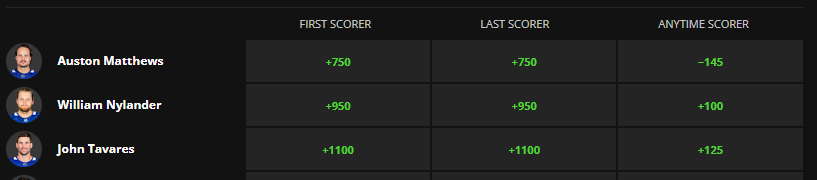

We can convert these odds to the implied probability that a player will score by:

If odds are positive (+100 or above):

P(implied_scoring_odds) = 100 / (odds + 100)

If odds are negative (-101 or below):

P(implied_scoring_odds) = (-odds) / (-odds + 100)

Now we have: 1) Each players goal/no goal performance by game during the 2022-2023 season  
2) Each players implied odds of scoring by a betting house

If we identify a situation where the P(implied_scoring_odds) < P(actual_scoring_odds) it might make sense for us to take a wager out on that player...

Assuming that the players performance will continue to follow their historical performance (a BIG assumption, even bigger an assumption if this data was during the playoffs for the Maple Leafs...), we can test whether or not the observed distribution is signficantly different from the implied probability from DraftKings.

We do this using a right tailed binomial test where:

H<sub>o</sub>: P(actual_scoring_odds) =< P(implied_scoring_odds)  
H<sub>a</sub>: P(actual_scoring_odds) > P(implied_scoring_odds)

If we reject the null hypothesis, we would have theoretically identified a player whose probability of scoring could be higher than that of the implied odds of DraftKings, possibly giving us an edge over the house. If this was the case - we could bet on that player and have a positive expected payout.

```python
def binomtest_modified(df, payout = -145, greater_or_less = 'greater'):
    '''df: series containing only successes or fails
    payout:the actual payout of success
    greater or less: whether we are testing for greater prob or less'''
    #favored
    if payout < 100:
        implied_prob = -payout/(-payout + 100)
    #+money
    else:
        implied_prob = 100 / (payout + 100)
    x = (df>=1).sum()
    n = len(df)
    actual_prob = x/n
    return binomtest(k=x, n=n, p=implied_prob, alternative=greater_or_less), implied_prob, actual_prob
```

```python
odds = [
['Auston Matthews',-145],
['William Nylander',100],
['John Tavares',125],
['Mitchell Marner',155],
['Michael Bunting',185],
['Calle Jarnkrok',265],
['Alexander Kerfoot',285],
['Sam Lafferty',265],
['Noel Acciari',340],
['Erik Gustafsson',380],
['Morgan Rielly',425],
['David Kampf',425],
['Wayne Simmonds',425],
['Zach Aston-Reese',550],
['Timothy Liljegren',550],
['TJ Brodie',600],
['Mark Giordano',750],
['Jake McCabe',750],
['Luke Schenn',900],
['Justin Holl',1200]]
ML_odds = pd.DataFrame(data = odds, columns = ['player','odds'])
```

```python
results = pd.DataFrame(columns = ['player','implied_odds','actual_odds','pval'])
index = 0
for player in ML_game_data['player_name'].unique():
    if len(ML_odds[ML_odds['player']==player])>0:
        #get the odds and results
        test_vals, implied_odds, actual_prob = binomtest_modified(ML_game_data[ML_game_data['player_name'] == player]['goals'],\
                                                                 payout = int(ML_odds[ML_odds['player']==player]['odds'].values[0]))

        results.loc[index,'player'] = player
        results.loc[index,'implied_odds'] = implied_odds
        results.loc[index,'actual_odds'] = actual_prob
        results.loc[index,'pval'] = test_vals.pvalue
        index +=1
results
```

|  | player | implied_odds | actual_odds | pval |
| --- | --- | --- | --- | --- |
| 0 | Mark Giordano | 0.117647 | 0.059701 | 0.962875 |
| 1 | Wayne Simmonds | 0.190476 | 0.0 | 1.0 |
| 2 | Luke Schenn | 0.1 | 0.052632 | 0.933353 |
| 3 | TJ Brodie | 0.142857 | 0.044444 | 0.991743 |
| 4 | John Tavares | 0.444444 | 0.363636 | 0.926777 |
| 5 | Calle Jarnkrok | 0.273973 | 0.25 | 0.707221 |
| 6 | Justin Holl | 0.076923 | 0.030303 | 0.966992 |
| 7 | Morgan Rielly | 0.190476 | 0.057692 | 0.998535 |
| 8 | Jake McCabe | 0.117647 | 0.032258 | 0.996049 |
| 9 | Erik Gustafsson | 0.208333 | 0.075758 | 0.999103 |
| 10 | Alexander Kerfoot | 0.25974 | 0.089552 | 0.999884 |
| 11 | William Nylander | 0.5 | 0.462687 | 0.768091 |
| 12 | Sam Lafferty | 0.273973 | 0.155172 | 0.988988 |
| 13 | Michael Bunting | 0.350877 | 0.238806 | 0.98233 |
| 14 | Mitchell Marner | 0.392157 | 0.343284 | 0.827267 |
| 15 | Noel Acciari | 0.227273 | 0.151515 | 0.952579 |
| 16 | Auston Matthews | 0.591837 | 0.466667 | 0.981552 |
| 17 | Zach Aston-Reese | 0.153846 | 0.080645 | 0.971045 |
| 18 | Timothy Liljegren | 0.153846 | 0.074074 | 0.974958 |
| 19 | David Kampf | 0.190476 | 0.104478 | 0.980816 |

From looking at the above, we see that no pvals are below our threshold and thus we cannot reject the null hypothesis for anyone of the Maple Leafs players.

No edge to be found over the house right now!

Interestingly, if we flip the hypothesis test and perform a left tailed test where:

H<sub>o</sub>: P(actual_scoring_odds) >= P(implied_scoring_odds)  
H<sub>a</sub>: P(actual_scoring_odds) < P(implied_scoring_odds)

We get some interesting results...

```python
results_left = pd.DataFrame(columns = ['player','implied_odds','actual_odds','pval'])
index = 0
for player in ML_game_data['player_name'].unique():
    if len(ML_odds[ML_odds['player']==player])>0:
        #get the odds and results
        test_vals, implied_odds, actual_prob = binomtest_modified(ML_game_data[ML_game_data['player_name'] == player]['goals'],\
                                                                 payout = int(ML_odds[ML_odds['player']==player]['odds'].values[0]),
                                                                 greater_or_less='less')

        results_left.loc[index,'player'] = player
        results_left.loc[index,'implied_odds'] = implied_odds
        results_left.loc[index,'actual_odds'] = actual_prob
        results_left.loc[index,'pval'] = test_vals.pvalue
        index +=1
results_left
```

|  | player | implied_odds | actual_odds | pval |
| --- | --- | --- | --- | --- |
| 0 | Mark Giordano | 0.117647 | 0.059701 | 0.09237 |
| 1 | Wayne Simmonds | 0.190476 | 0.0 | 0.064119 |
| 2 | Luke Schenn | 0.1 | 0.052632 | 0.165587 |
| 3 | TJ Brodie | 0.142857 | 0.044444 | 0.03497 |
| 4 | John Tavares | 0.444444 | 0.363636 | 0.11507 |
| 5 | Calle Jarnkrok | 0.273973 | 0.25 | 0.401011 |
| 6 | Justin Holl | 0.076923 | 0.030303 | 0.10865 |
| 7 | Morgan Rielly | 0.190476 | 0.057692 | 0.00633 |
| 8 | Jake McCabe | 0.117647 | 0.032258 | 0.018286 |
| 9 | Erik Gustafsson | 0.208333 | 0.075758 | 0.003167 |
| 10 | Alexander Kerfoot | 0.25974 | 0.089552 | 0.000446 |
| 11 | William Nylander | 0.5 | 0.462687 | 0.312703 |
| 12 | Sam Lafferty | 0.273973 | 0.155172 | 0.025248 |
| 13 | Michael Bunting | 0.350877 | 0.238806 | 0.033586 |
| 14 | Mitchell Marner | 0.392157 | 0.343284 | 0.245387 |
| 15 | Noel Acciari | 0.227273 | 0.151515 | 0.08903 |
| 16 | Auston Matthews | 0.591837 | 0.466667 | 0.03373 |
| 17 | Zach Aston-Reese | 0.153846 | 0.080645 | 0.069789 |
| 18 | Timothy Liljegren | 0.153846 | 0.074074 | 0.06681 |
| 19 | David Kampf | 0.190476 | 0.104478 | 0.043845 |

We see that we reject the null hypothesis for several players in this game. The implication of this is that their is a statistically significant *lower* probability to score on 3/13 than is implied by the DraftKings lines. Unfortunately for us, we are unable to bet on this as it is not currently offered.

```python
results_left[results_left['pval']<.05]
```

|  | player | implied_odds | actual_odds | pval |
| --- | --- | --- | --- | --- |
| 3 | TJ Brodie | 0.142857 | 0.044444 | 0.03497 |
| 7 | Morgan Rielly | 0.190476 | 0.057692 | 0.00633 |
| 8 | Jake McCabe | 0.117647 | 0.032258 | 0.018286 |
| 9 | Erik Gustafsson | 0.208333 | 0.075758 | 0.003167 |
| 10 | Alexander Kerfoot | 0.25974 | 0.089552 | 0.000446 |
| 12 | Sam Lafferty | 0.273973 | 0.155172 | 0.025248 |
| 13 | Michael Bunting | 0.350877 | 0.238806 | 0.033586 |
| 16 | Auston Matthews | 0.591837 | 0.466667 | 0.03373 |
| 19 | David Kampf | 0.190476 | 0.104478 | 0.043845 |

Out of all the players above, none of the players scored on 3/13. It is worth noting that the line likely would have changed and we would have had to contend with a

P(player_doesn't_score) not being = 1 - P(player_scores)

but it is still worth keeping an eye out for if the betting houses ever add the ability to bet on a player not scoring...

# Conclusions

Although we were not able to identify any players that we would have liked to have placed a wager on 3/13, we can expand this methodology broadly to the entire league and all of the players who would have goal-scorer lines available to them.

It is also worth noting that we seem to have evidence that the likelihood for many players to score is even *lower* than the odds given to us, indicating that the "haircut" betting houses introduce might be fairly large for players scoring.